# sl.hw 2

chiara

5/28/2021

## Ex.1

### Define the Bayes classifier/strategy and briefly explain its role/importance in classification/prediction.

Bayes classifiers are a collection of classification algorithms based on **Bayes’ theorem**. It is not a single algorithm, but a family of algorithms where all of them share a common principle, that is *every pair of features being classified is independent of each other and contibutes equally to the outcome of the dependent variable*. Even though these assumptions do not generally hold in real examples, they work well in practice.

The Bayes classifier finds the corresponding labelling class for every pair of fatures by using the maximum a posteriori, **it achieves the lowest possible error(like an irreducible variance)** among all type of classifiers (this is true if all the terms involving Bayes’ theorem are corectly specified). Hence its importance comes from the fact that all types of classifiers try to perform **at least as well as the Bayes classifier: it’s the optimal classifier**.

**Let Y represent the dependent variable and X the independent variable, the rule of the Bayes classifier is defined as follows using Bayes’ theorem
$$p(Y=c|X)= \frac{p(X|Y=c)p(Y=c)}{p(X)}$$
Assuming binary classification setting with two predictors, we can then define the previous equation as follows:
$$p(Y=1|X_1, X_2)= \frac{p(X_1,X_2|Y=1)p(Y=1)}{p(X_1,X_2|Y=0)p(Y=0)+p(X_1,X_2|Y=1)p(Y=1)}$$
Since Bayes classifier assumes independency for the predictors and the denominator is just a normalizing constant, we can then write:
$$p(Y=1|X_1, X_2) \propto p(X_1|Y=1)p(X_2|Y=1)p(Y=1)$$
Writing the same in the case of $Y=0$, we can then write:
$$\underset{y} \argmax p(y|X_1, X_2) \propto \prod_{i=1}^2 p(X_i|y)p(y)$$

where $p(y)$ is the a priori probability associated with a given class, and $p(X_i|y)$ is the likelihood of a predictor coming from a certain class. By using Bayes theorem, the Bayes classifier assigns a a given pair of featues to the class that maximized the a posteriori probability. Given a data set, we need to assume a distribution for the likelihood and compute the a priori probabilities; the Bayes classifier is a *generative approach*.

### Simulate n = 250 data from the joint data model p(y, x) = p(x | y) · p(y)

```r
set.seed(20)

joint=function(n){
  y=matrix(NA, n, 1)
  x_cond_y=matrix(NA, n, 1)
  for (i in 1:n) {
    y[i]=rbinom(1,1,0.5) #the marginal distribution of Y is Bernoulli with success probability 0.5
    x_cond_y[i]=ifelse(y[i]==0, runif(1, min = -3, max=1), runif(1, min = -1, max=3))
    #this command generates the conditional probability of X given Y, if the observed value of Y is 0, then the conditional distribution of X is uniform between -3 and 1, otherwise the conditional distribution of X is uniform between -1 and 3
  }
  joint=cbind(y, x_cond_y)
  return(joint)

  }

sample=joint(250) #our sample of 250 observations of (Y,X)


head(sample)#just to verify that the function works correctly
```

```
##      [,1]       [,2]
## [1,]    1  2.0741328
## [2,]    0 -0.8833452
## [3,]    1  2.9214183
## [4,]    0 -2.7170021
## [5,]    0 -1.5197018
## [6,]    1  2.0311854
```

### Plot the data together with the regression function that defines hopt(x)

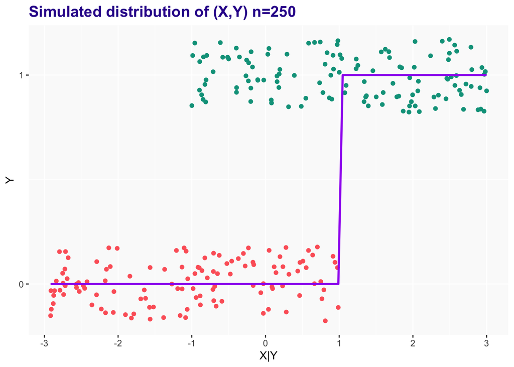

```r
ind_1_3=function(x){
  value=ifelse(x>1 & x<3, 1, 0) #indicator function between 1 and 3
  return(value)
}

library(ggplot2)
s=data.frame(sample)
ggplot(s, aes(X2,X1))+ geom_jitter(height = 0.18,aes(color = factor(X1)))+theme(panel.background = element_rect( fill = "#FAFAFA"))+ scale_y_continuous(breaks =c(0,1), labels = c("0","1"))+ theme(legend.position = "none")+ scale_color_manual(values = c("#FD6467", "#00A08A"))+stat_function(fun=ind_1_3, col="purple", size=1)+xlab("X|Y")+ylab("Y")+labs(title= "Simulated distribution of (X,Y) n=250")+theme(plot.title = element_text(color="#330099", size=15, face="bold"))
```

### Evaluate the performance of the Bayes Classifiers on these simple (only 1 feature!) data

```r
#we have computed the naive bayes classifier as the indicator fnc of x between 1 and 3
h_opt=function(x) {
  y_bay=matrix(NA, length(x), 1) #empty vector to store the classification

  for (i in 1:length(y_bay)) {
   y_bay[i]=ind_1_3(x[i])#if the i-th x is between 1 and 3 then the bayes classifier assigns to the yi-th y value 1, 0 otherwise
  }
  joint_bay=cbind(y_bay,x)  #returns the joint with the bayesian classification for y
  return(joint_bay)
}


bayes_est=h_opt(sample[,2]) #we are applying the bayes classifier to the generated x values

head(bayes_est)
```

```
##                 x
## [1,] 1  2.0741328
## [2,] 0 -0.8833452
## [3,] 1  2.9214183
## [4,] 0 -2.7170021
## [5,] 0 -1.5197018
## [6,] 1  2.0311854
```

```r
eval=function(y_bay){
  errors=matrix(NA, length(y_bay), 1) #empty vector to store any misclassification
  errors=abs(y_bay-sample[,1])
    return(sum(errors)/length(errors)) #returns the misclassification rate
}

eval(bayes_est[,1]) #our bayesian estimator is wrong 24% of the times
```

```
## [1] 0.24
```

#### Comparison with the r version of naive Bayes classifier

```r
library(e1071)
naive.r=naiveBayes(X1 ~ ., data = s, type = "raw")

pred.r = predict(naive.r, s)

mean(pred.r !=  s$X1)*100  #they produce the same results
```

```
## [1] 24
```

```r
library(caret)
confusionMatrix(pred.r, as.factor(s$X1))
```

```
## Confusion Matrix and Statistics
##
##           Reference
## Prediction  0  1
##          0 92 31
##          1 29 98
##
##                Accuracy : 0.76
##                  95% CI : (0.7021, 0.8116)
##     No Information Rate : 0.516
##     P-Value [Acc > NIR] : 1.873e-15
##
##                   Kappa : 0.5198
##
##  Mcnemar's Test P-Value : 0.8973
##
##             Sensitivity : 0.7603
##             Specificity : 0.7597
##          Pos Pred Value : 0.7480
##          Neg Pred Value : 0.7717
##              Prevalence : 0.4840
##          Detection Rate : 0.3680
##    Detection Prevalence : 0.4920
##       Balanced Accuracy : 0.7600
##
##        'Positive' Class : 0
##
```

The “hand-made” Bayes classifier and the r-based one yeald the same result, as expected. The r-Bayes classifier is wrong 24% of the times too.

### Apply any other classifier of your choice to these data and comparatively comment its performance.

We have chosen to compare the Bayes classifier to the logistic one. The main difference between the classifiers resides in their nature: the Bayes one is generative, while the logistic is discriminative. In fact the logistic classifier optimizes the conditional distribution of Y given the features.

```r
library(arm)
fit.1 <- glm (sample[,1] ~ sample[,2], family=binomial(link="logit"))
log_y = ifelse(predict(fit.1) > 0.5, 1, 0) #this is the logistic classification for Y

eval(log_y) #the logistic classifier is wrong 24% of the time
```

```
## [1] 0.24
```

The logistic classifier exhibits the same error rate as the Bayes one.

### Repeat the sampling M = 1000 times keeping n = 250 fixed (a simple for-loop will do it), and redo the comparison

#### Bayes repetition

```r
mtx <- array(NA, c(250, 2, 1000)) #we create a 1000 empty 250x2 matrices
M=1000
for (i in 1:M) {
  ith_joint=joint(250) #we simulate the ith sample
  mtx[,1,i]=ith_joint[,1] #we fill rows and columns of each of the 1000 matrices
  mtx[,2,i]=ith_joint[,2]
}


##1000 bayes classifiers
bayes_rep=matrix(NA, 250, 1000) #each of the 1000 columns contains the classifier for the ith sample (contains 1000 Y vectors)

for (i in 1:M) {
  bayes_rep[,i]=h_opt(mtx[,2,i])[,1]
} #we apply the bayes classifier to the 1000 simulated Ys, stored in "bayes_rep"

bayes_error=matrix(NA, 1000, 1) #each row is going to contain the error rate computed at one of the 1000 simulations

for (i in 1:M) {
  bayes_error[i]=eval(bayes_rep[,i])
}

mean(bayes_error)
```

```
## [1] 0.508552
```

By simulating a 1000 (Y,X) vectors, we observe that on average the Bayes classifier misclassifies observations around 50.8% of the times.

#### Logistic repetition

```r
###1000 logistic classifiers
M=1000
logit_rep=matrix(NA, 250, 1000)

errors_logit=matrix(NA,1,1000) #empty, contains the error rates for each of the 1000 simulatios



for (j in 1:M) {
  fit.j <- glm (mtx[,1,j] ~ mtx[,2,j], family=binomial(link="logit")) ##fitting the logistic model on the j-th sampled data
  log_yj = ifelse(predict(fit.j) > 0.5, 1, 0) #this is the logistic classification for Yj
  logit_rep[,j]=log_yj
  errors_logit[j]=eval(log_yj)

}

mean(errors_logit) #error rate of the logistic regression
```

```
## [1] 0.502628
```

By simulating a 1000 (Y,X) vectors, we observe that on average the logistic classifier misclassifies observations around 50.3% of the times, which is approximately the same result obtained by evaluating the Bayes classifier.